# This data is about Fifa 19 players

**this dataset is not included in as one of the provided by udacity i simply saw that it's a good data set and will get good visuals from it**

## invastegation overview:

- The data needed to be cleaned espcially the Value and Wage parts to extract the values correctly
- International reputation palyes a huge role in the data
- Value and Wage columns most of the time have +ve relation with other columns

## Which Club is willing to pay above average Wage

**why i specifically wanted to know the top clubs in paying wage?**

to see if paying more is winning more and it really looks like that having better players that ask for more money results in winning more

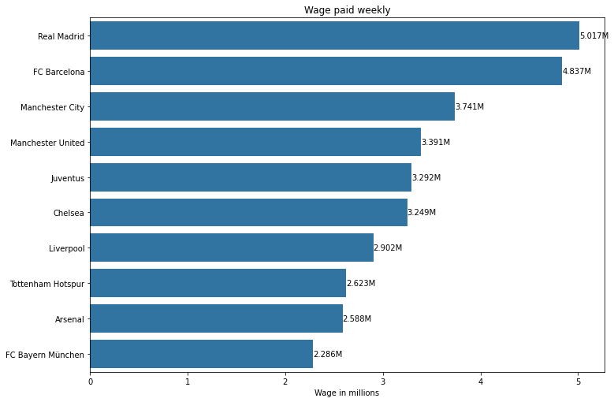

## Clubs that have the most valuable players

**What this plot proves?**

this plot proves that paying more is winning more most of the last top 10 list is here in this plot and there is something in common in between all these clubs that they all are popualr and have a decent chang in winnig big titles

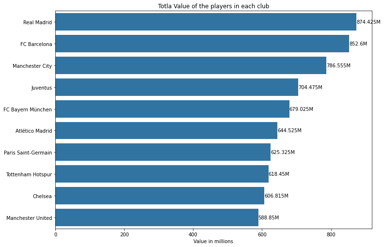

## Top 10 paid players

**who are the top paid players and why are they top paid?**

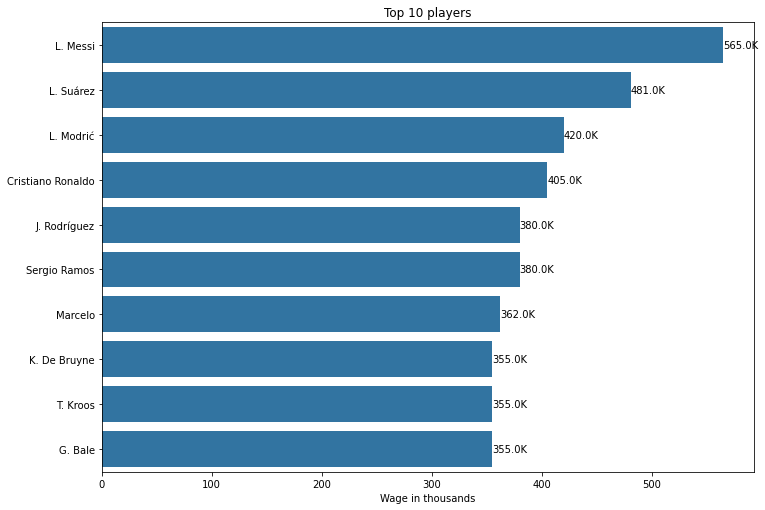

## Relation between age and International Reputation

**As we see in the visualization ahead that compares age and reputation of the players and reputation is from 1 to 5 and 5 is the highest majorty of players as we see have one and only few got 5, I also noticed that as the reputation score increses the box plot is not as spread which and it shrinks on both sides wich means that players need to be not only have crazy status but also have experience and looks like ages between 25 to 35 is where players have 4 and 5 rep points because usally this is the prime years of a player**

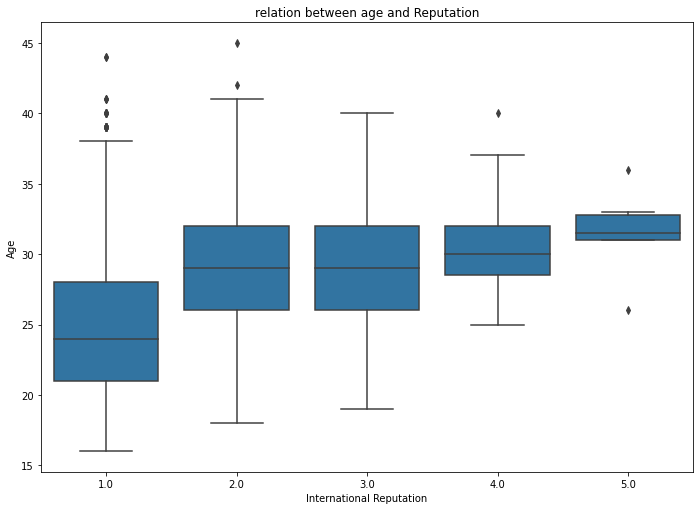

## Relation between Overall and Wage

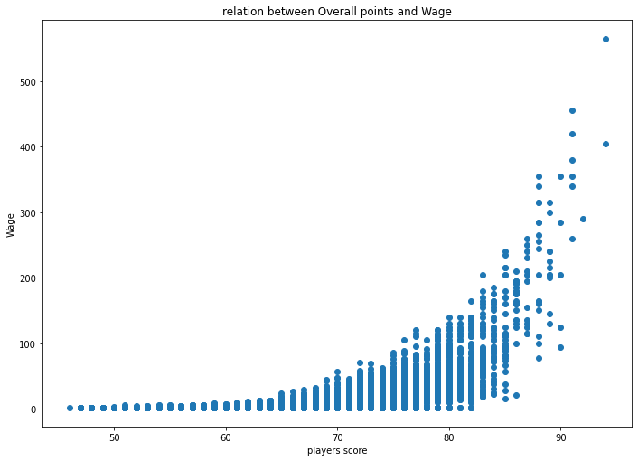

## Relation between Potential and International Reputation

**In this visualization we see that as the potential of players increase rep shrinks high rep like 4 and 5 is only for palyers in range 80's to 90's and there are not outliers but in the ranks 1 and 2 there is ton of outliers from that visual it seems that rep depends on many things potential is one of them but it's not a main reason because there is a lot of rank 2 players in the range of rank 4 and 5**

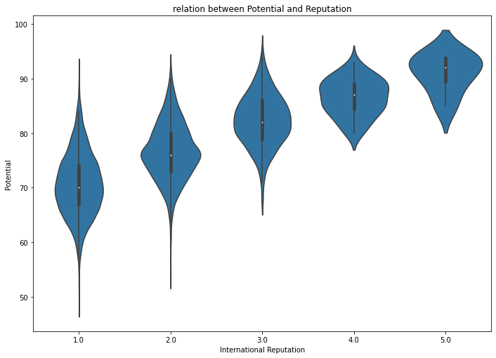

## Relation between Overall, Wage and International Reputation

**This plot shows us that players with high overall not only gain more Wage as a player it also gives the player high international reputation of course its not the only factor for high Rep but it's one of the reasons**

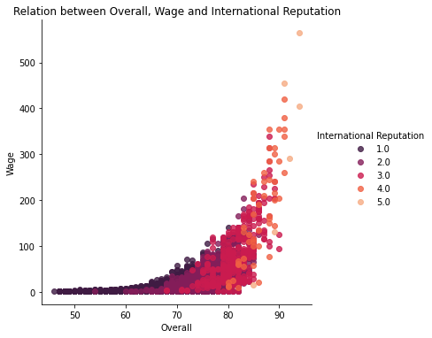